```python
from IPython.display import HTML
HTML('''<script>
code_show=true;
function code_toggle() {
 if (code_show){
 $('div.input').hide();
 } else {
 $('div.input').show();
 }
 code_show = !code_show
}
$( document ).ready(code_toggle);
</script>
 <form action="javascript:code_toggle()"><input type="button" onclick="$('div.input').hide();" value="Hide Code"></form>''')
```

```python
from IPython.display import HTML
HTML('''<script>
code_show=true;
function code_toggle() {
 if (code_show){
 $('div.input').hide();
 } else {
 $('div.input').show();
 }
 code_show = !code_show
}
$( document ).ready(code_toggle);
</script>
 <form action="javascript:code_toggle()"><input type="submit" value="Click here to toggle on/off the full code."></form>''')
```

# Building Probability of Default Model on Fannie Mae acquired loans

## 1) Description:

Building probabiliyt of default model using Fannie Mae Single Family Fixed Rate Mortgage Datasets. Fannie Mae provides loan acquisition and performance data on a portion of its single-family mortgage loans to promote better understanding of the credit performance of Fannie Mae mortgage loans. The population includes two datasets.

The datasets consist of two tables - (i) Acquisition Data & (ii) Performance Data. Every quarter, the repository is updated to add another quarter of acquisitions and performances.

*Reference Link:* - [Fannie Mae](https://loanperformancedata.fanniemae.com/lppub/index.html#Portfolio)

## 2) Variable Definition

Definition of few key metrics used in model development

- Loan_IDENTIFIER: Unique key for borrowers
- Default Flag: Whether a loan defaults in 12 months after acquired by Fannie Mae. 0 if the loan is performing, 1 if the laon defaults.
- Loan to Value(LTV) - Reflects the loan-to-value ratio of the loan amount secured by a mortgaged property on the origination date of the underlying mortgage loa
- Combined Loan to Value(LTV) - Reflects the loan-to-value ratio inclusive of all loans secured by a mortgaged property on the origination date of the underlying mortgage loan.
- Debt to Income Ratio - Ratio of borrower’s total monthly obligations (including housing expense) by his or her stable monthly income
- Loan Purpose: Indicator denoting type of mortgage loan
  - P - Purchase Mortgage
  - C - Cash Out Mortgage
  - R - No Cash Out Mortgage
  - U - Refinance Mortgage Purpose may be the purchase of a new property or refinance of an existing lien (with cash out or with no cash out).

## 3) Event Definition - Default

Borrowers are said to be non perfrofming or defaulting the loan when they have missed the monthly paymnets for 90 days(3 Months). But since majority of Fannie Mae acquired mortgage are prime loans, the number of defaults using conventional definition is too low(< 0.05%).

Hence, for this case study, the default is taken as loan that failed to meet the monthly payment obligations for two months or more.

## 4) Key Challenges

Main obstacles while developing the default model were:

- Imbalanced Dataset - Fannie Mae has specific criteria basis which a loan is acquired. The acquired loans are then bundled together and sold as Securities(MBS) to general public. Hence, majority of the loans are of prime lending resulting in very low number of defaulters.
- Absence of key informations - Since Fannie Mae is providing this data publically, the information captured are very superficial thus impacting the performance of model developed.

```python
from Custom_Functions_v16 import Plot_Confusion_Matrix, Plot_ROC_Curve, Save_pkl_txt_files, Feature_Importance_Plot

import sys
sys.path.append('C:\\Users\\SDwivedi\\AppData\\Local\\Programs\\Python\\Python37\\Lib\\site-packages')

import warnings
warnings.filterwarnings('ignore')

import pandas as pd
import numpy as np

import matplotlib.pyplot as plt
plt.rc("font", size=14)

import seaborn as sns
sns.set(style="whitegrid", color_codes=True)

import itertools
from sklearn.metrics import confusion_matrix, precision_recall_curve, auc, roc_auc_score, roc_curve, recall_score, classification_report
from sklearn.metrics import accuracy_score

from sklearn.model_selection import GridSearchCV
from sklearn.linear_model import LogisticRegression

from sklearn.preprocessing import LabelEncoder

from sklearn import preprocessing

from sklearn.cross_validation import train_test_split

import _pickle as pickle
import requests
import json

import vertica_python as vc
from imblearn import under_sampling, over_sampling
from imblearn.over_sampling import SMOTE

warnings.filterwarnings('ignore')
```

#### We have the FM data in Vertica, a Column based DMBS, supporting quick execution of queries.

```python
conn_info = {'host': '13.232.211.49',
             'port': 5433,
             'user': 'dbadmin',
             'password': 'P0tom@c@207',
             'database': 'POTOMACDB',
             'read_timeout': 60000
            }
connection = vc.connect(**conn_info)
cur = connection.cursor()
cur.execute("select * from fannie_mae.training_data")
result = pd.DataFrame(cur.fetchall())
colnames = pd.DataFrame(cur.description)
colnames2 = list(colnames.iloc[:,0].T)
result.columns = colnames2
# result.to_csv('C:/Users/SDwivedi/Fannie Mae/Data from Vertica/Data/training_data', sep='\t')
```

```python
indata = result.copy()

indata.drop(["obs_rank","property_state","current_interest_rate","origination_date",
           "monthly_reporting_period","maturity_date","current_loan_delinquency_status","vint_orgn","obs_rank","servicer_name",
           "zip","qtr_orgn","month_defaulting","metropolitan_statistical_area","seller_name","mortgage_insurance_percentage"],
            axis=1, inplace=True)
```

```python
int_cols = ["original_interest_rate","original_loan_term","original_unpaid_principal_balance",
            "original_loan_to_value","original_combined_loan_to_value","number_of_borrowers","debt_to_income_ratio",
            "borrower_credit_score","number_of_units","coborrower_credit_score",
            "default_flag","loan_id_perf"]
char_cols = ["origination_channel","first_time_home_buyer_indicator","loan_purpose","property_type","occupancy_status",
             "relocation_mortgage_indicator",
             "mortgage_insurance_type"]
```

```python
indata[int_cols]  = indata[int_cols].fillna(np.nan)
indata[char_cols] = indata[char_cols].fillna('NA')
indata['mortgage_insurance_type'] = 'Check-' + indata['mortgage_insurance_type'].astype(str)
```

```python
for i in int_cols:
    indata[i] = indata[i].astype(np.float64)
```

```python
# result.dtypes.value_counts()
# indata.dtypes.value_counts()
```

## 5) Data Visualization:

### Distribution of Good v/s Bad(default) Loans

```
The distribution of Target Variable -

default_flag  # Loans
         0.0   400000
         1.0     1484

Borrowers who defaulted are tagged as 1, others as 0.

This is a highly imbalanced dataset with minority class as :0.371 % of total data points.

Training data shape:  (401484, 19)
```

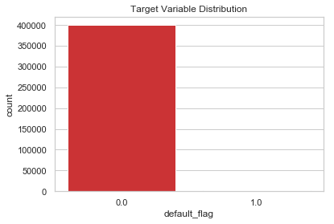

```python
d1 = pd.DataFrame(indata.groupby(['default_flag']).size().to_frame('# Loans').reset_index())
NDeflt = d1.iloc[0,1]
Deflt  = d1.iloc[1,1]

print('The distribution of Target Variable -\n')
print(indata.groupby(['default_flag']).size().to_frame('# Loans').reset_index().to_string(index=False))
print('\nBorrowers who defaulted are tagged as 1, others as 0.\n')
print('This is a highly imbalanced dataset with minority class as :' + str(round(100*Deflt/NDeflt,4)) + ' % of total data points.')
print('\nTraining data shape: ', indata.shape)

ax = sns.countplot(x="default_flag", data=indata, palette = "Set1").set_title('Target Variable Distribution')
plt.show()
```

```python
#### -- Get Classes / Levels of a categorical Variable -- ####
def getclasses(df):
    i = 0
    F = pd.DataFrame()
    for c in df.select_dtypes(include = ['object']).columns:
        if c != 'mortgage_insurance_type':
            t_i = pd.DataFrame(df[c].unique()).rename(columns={0: c}).sort_values(by=c).reset_index()
        else:
            t_i = pd.DataFrame(df[c].unique()).rename(columns={0: c}).reset_index()

        F = pd.concat([F, t_i.iloc[:,1]], axis=1)
        i += 1

    F = F.replace(np.nan, '', regex=True).T

    NClass = []
    for r in range(0,len(F)):
        i = 0
        robs = F.iloc[r,:]
        for c in robs:
            if (c == ""):
                continue
            else:
                i +=1
        NClass.append(i)

    df2 = F
    df2['NClass'] = NClass

    cols = df2.columns.tolist()
    cols = cols[-1:] + cols[:-1]
    df2 = df2[cols]
    return df2.sort_values('NClass', ascending = False)

#### -- Fields with Missing Values -- ####
def missing_values_table(df):
        mis_val = df.isnull().sum()
        mis_val_percent = 100 * df.isnull().sum() / len(df)
        mis_val_table = pd.concat([mis_val, mis_val_percent], axis=1)
        mis_val_table_ren_columns = mis_val_table.rename(
        columns = {0 : 'Missing Values', 1 : '% of Total Values'})

        mis_val_table_ren_columns = mis_val_table_ren_columns[
            mis_val_table_ren_columns.iloc[:,0] != 0].sort_values('% of Total Values', ascending=False).round(1)

        print ("Given data has " + str(df.shape[1]) + " columns.\n" +
            str(mis_val_table_ren_columns.shape[0]) + "columns have missing values with following frequencies.")

        # Return the dataframe with missing information
        return mis_val_table_ren_columns
```

### Categorical Variables & Corresponding Classes:

The Following table gives the information on Categorical information present and levels for each of them.

```python
getclasses(indata)
```

|  | NClass | 0 | 1 | 2 | 3 | 4 |
| --- | --- | --- | --- | --- | --- | --- |
| property_type | 5 | CO | CP | MH | PU | SF |
| origination_channel | 3 | B | C | R |  |  |
| loan_purpose | 3 | C | P | R |  |  |
| occupancy_status | 3 | I | P | S |  |  |
| mortgage_insurance_type | 3 | Check-NA | Check-1 | Check-2 |  |  |
| first_time_home_buyer_indicator | 2 | N | Y |  |  |  |
| relocation_mortgage_indicator | 2 | N | Y |  |  |  |

### Fields with Missing Values:

Parameters with missing values.

```python
missing_values_table(indata)
```

```
Given data has 19 columns.
3columns have missing values with following frequencies.
```

|  | Missing Values | % of Total Values |
| --- | --- | --- |
| coborrower_credit_score | 173756 | 43.3 |
| borrower_credit_score | 177 | 0.0 |
| debt_to_income_ratio | 44 | 0.0 |

A normalized credit score is created by taking the mean of borrower_credit_score & coborrower_credit_score are for loans with two or more borrowers. Each of latter two columns are then removed from the final model development.

## 6) Analyzing Categorical and Continuos Variables

### Plotting categorica and continuos variables wrt to target behavior to see ig there is any association between the fields and the default.

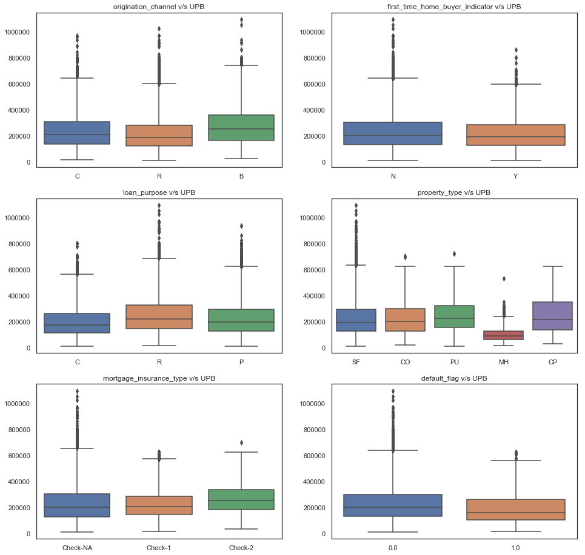

```python
list1 = ['origination_channel', 'first_time_home_buyer_indicator','loan_purpose',
         'property_type','mortgage_insurance_type', 'default_flag']

r = 3
c = 2

sns.set(style="white", color_codes=True)
fig, axes =plt.subplots(r,c,figsize=(16,16))

for i in range(0,r):
    for j in range(0,c):
        col_num = i*c + j
        col = list1[col_num]
        sns.boxplot(x=col, y='original_unpaid_principal_balance', data=indata, whis = 2, ax = axes[i][j]).set_title(col + ' v/s UPB')
        axes[i][j].set_xlabel('')
        axes[i][j].set_ylabel('')
```

As can be seen from the above box plot, the average loan amount sanctioned is fairly same accross the three purposes.

#### Effect of Credit Score, Debt to Income, CLTV and LTV on Default

The following plots clearly shows the impact of Credit Score, Debt to Income and LTV on Default. Borrower's tendency to default on loan is more for borrowers with lower credit score and higher LTV/DTI/CLTV ratio.

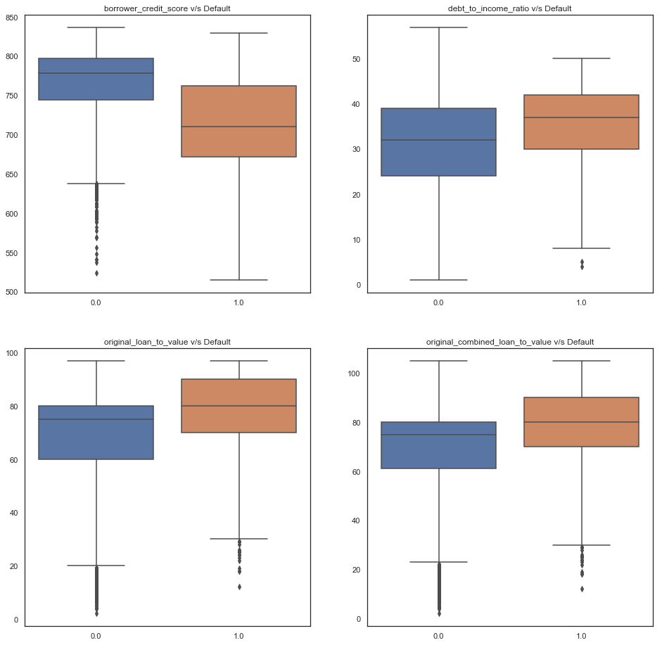

```python
list1 = ['borrower_credit_score', 'debt_to_income_ratio',
         'original_loan_to_value','original_combined_loan_to_value']

r = 2
c = 2

sns.set(style="white", color_codes=True)
fig, axes =plt.subplots(r,c,figsize=(16,16))

for i in range(0,r):
    for j in range(0,c):
        col_num = i*c + j
        col = list1[col_num]
        sns.boxplot(x='default_flag', y=col, data=indata, whis = 2, ax = axes[i][j]).set_title(col + ' v/s Default')
        axes[i][j].set_xlabel('')
        axes[i][j].set_ylabel('')
```

#### Frequency Distribution of Categorical behavior wrt Default Behavior

The following plots shows that the fileds - of Loan Purpose and Fist Time Home buyer Indicator, has different distribution amongst Performing and non performing Loans. Hence, the fields are important to retain in the developed model.

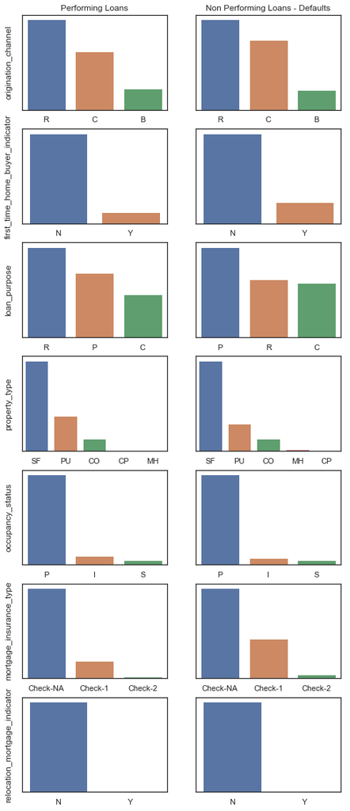

```python
list1 = list(indata.select_dtypes('object').columns)
r = len(list1)
c = 2

sns.set(style="white", color_codes=True)
fig, axes =plt.subplots(r,c,figsize=(8,20))

for i in range(0,r):
    col_num = i
    col = list1[col_num]

    DefaultData = indata[indata.default_flag==1][col].value_counts(normalize=True).reset_index().rename(columns={col: "norm_values", "index" : col})
    NDefaultData = indata[indata.default_flag==0][col].value_counts(normalize=True).reset_index().rename(columns={col: "norm_values", "index" : col})

    sns.barplot(x=col, y="norm_values", data=NDefaultData, ax = axes[i][0])
    sns.barplot(x=col, y="norm_values", data=DefaultData, ax = axes[i][1])

    if i == 0:
        axes[i][0].set_title('Performing Loans')
        axes[i][1].set_title('Non Performing Loans - Defaults')

    axes[i][0].set_xlabel('')
    axes[i][0].set_ylabel(col)
    axes[i][1].set_xlabel('')
    axes[i][1].set_ylabel('')
    axes[i][0].set_yticklabels(())
    axes[i][1].set_yticklabels(())
```

## <font color = green>7) Correlation Matrix</font>

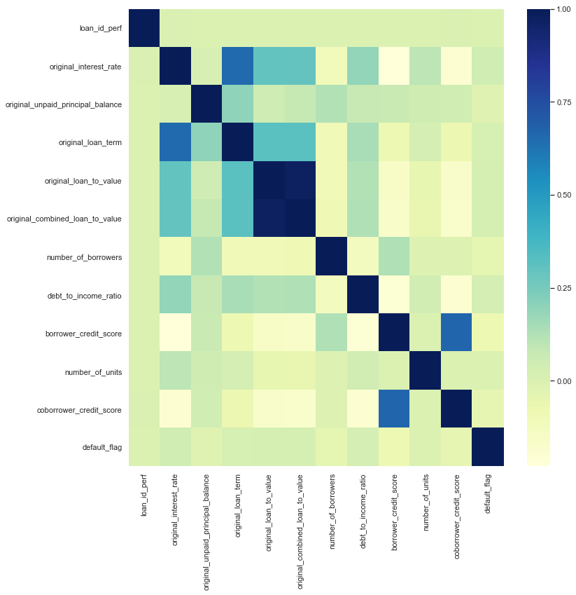

```python
fig, ax =plt.subplots(figsize=(12,12))
sns.heatmap(indata.corr(), cmap="YlGnBu")
plt.show()
# -- Might have to look to drop Highly Correlated Variables
```

```python
Retain_Features = ['loan_id_perf','origination_channel','original_interest_rate','property_type','number_of_borrowers',
                   'original_combined_loan_to_value','debt_to_income_ratio','first_time_home_buyer_indicator',
                   'number_of_units','mortgage_insurance_type','default_flag','loan_purpose','coborrower_credit_score',
                   'relocation_mortgage_indicator','original_loan_term','original_loan_to_value',
                   'borrower_credit_score','occupancy_status','original_unpaid_principal_balance']

indata2 = pd.DataFrame()

for c in Retain_Features:
    indata2[c] = indata[c]
```

## 8) Feature Engineering

Following changes were made to the dataset to have a more representative sample.

- Creating New Fields Basis Domain Knowledge - Formulated aggregated credit score as FICO instead of having two fields - Borrower's and Coborrower's Credit Score. The formulated varaible had a correlation of 95.87% with the Borrower's Credit Score ensuring that the variance/insight is not lost.
- Removed Fields that doesnt affect the loan approval UW process - Basis US Fair Lending Act(Truth in Lending Act), ECOA prohibits discrimination based on race, color, religion, national origin, demographs, sex, marital status, age, source of income or whether a person exercises rights granted under the Consumer Credit Protection Act for any credit transaction and through the life of the loan.
- Polynomial Features - Non-Lilnear features were created basis the most relevant fields in the data. However, the new features were not contributing to enhancement of model performance and hence removed.

```python
indata2['FICO'] = np.where(indata2.number_of_borrowers > 1,
                          (indata2.coborrower_credit_score + indata2.borrower_credit_score)/2,
                          indata2.borrower_credit_score)
```

```python
# print("Correlation between FICO and Borrower's Credit Score - " + str(indata2['FICO'].corr(indata2['borrower_credit_score']).round(5)*100) + '%')
```

```python
del indata2['borrower_credit_score']
del indata2['coborrower_credit_score']
indata2.dropna(how='any', inplace = True)
```

## 9) Converting Categorical Fields to Numerical Variables:

Since Python ML library(Scikit-Learn) done not cater to categorical parameters, we need to transform such columns to numerical type using one of the two encoding methods: a) Label Encoding b) One Hot Encoding

*Reference Link:* - [Types of Encoding](https://medium.com/@contactsunny/label-encoder-vs-one-hot-encoder-in-machine-learning-3fc273365621)

```python
ncols = len(list(indata2.columns))
features_name = list(indata2.columns)

le = LabelEncoder()
le_count = 0

# Iterate through the columns
for col in indata2:
    if indata2[col].dtype == 'object':
        if len(list(indata2[col].unique())) <= 2:
            le.fit(indata2[col])
            indata2[col] = le.transform(indata2[col])
            le_count += 1

ncols = len(list(indata2.columns))
ncols_after_label = len(list(indata2.select_dtypes(include='object').columns))
indata2 = pd.get_dummies(indata2)
```

```python
print('# of Columns in dataset - %d' %ncols)
print('# Columns that were Label Encoded - %d' % le_count)

print('# Columns that were One Hot Encoded - %d' %ncols_after_label)
print('Final shape of dataset after Encoding - ', indata2.shape)
```

```
# of Columns in dataset - 18
# Columns that were Label Encoded - 2
# Columns that were One Hot Encoded - 5
Final shape of dataset after Encoding -  (401049, 30)
```

## 10) Splitting Data into Training and Validation Set:

```python
indata3 = indata2.copy()
indata3 = indata3.set_index('loan_id_perf')

list1 = (indata3.columns)
features = ','.join(list1)

y = indata3.default_flag
X = indata3.drop(['default_flag'], axis=1)

features_list = list(X.columns)

X_train, X_test, y_train, y_test = train_test_split(X, y, test_size=0.30, random_state=0)
print('# of observations in Training Data - ' + str(X_train.shape[0]) + '\n# of observations in Testing Data  - ' + str(X_test.shape[0]))
```

```
# of observations in Training Data - 280734
# of observations in Testing Data  - 120315
```

## Model Development - Logistic Regression - Synthetic Minority Over Sampling Technique(SMOTE)

This dataset is a typical example of an imbalanced classification. This is a scenario where the number of observations belonging to one class is significantly lower than those belonging to the other classes.In this situation, the predictive model developed using conventional machine learning algorithms could be biased and inaccurate.

This happens because Machine Learning Algorithms are usually designed to improve accuracy by reducing the error. Thus, they do not take into account the class distribution / proportion or balance of classe and predicts all the samples to be from majority calss.

SMOTE is a technique where data is taken from the minority class as an example and then new synthetic similar instances are created. The created samples are are created basis the linearity of the given minority class. These synthetic instances are then added to the original dataset. The new dataset is used as a sample to train the classification models.

[figure not shown]

```python
# ------------------------ SMOTE - Logistic Regression ------------------------ #

print("Before OverSampling, counts of label '1': {}".format(sum(y_train==1)))
print("Before OverSampling, counts of label '0': {} \n".format(sum(y_train==0)))

print('Before OverSampling, the shape of train_X: {}'.format(X_train.shape))
print('Before OverSampling, the shape of train_y: {} \n'.format(y_train.shape))

sm = SMOTE(random_state=2)
X_train_res, y_train_res = sm.fit_sample(X_train, y_train.ravel())

print('After OverSampling, the shape of train_X: {}'.format(X_train_res.shape))
print('After OverSampling, the shape of train_y: {} \n'.format(y_train_res.shape))

print("After OverSampling, counts of label '1': {}".format(sum(y_train_res==1)))
print("After OverSampling, counts of label '0': {}".format(sum(y_train_res==0)))
```

```
Before OverSampling, counts of label '1': 1014
Before OverSampling, counts of label '0': 279720

Before OverSampling, the shape of train_X: (280734, 28)
Before OverSampling, the shape of train_y: (280734,)

After OverSampling, the shape of train_X: (559440, 28)
After OverSampling, the shape of train_y: (559440,)

After OverSampling, counts of label '1': 279720
After OverSampling, counts of label '0': 279720
```

## Using Cross Validation to get Best Fit

Steps invloved in K-Fold Cross Validation -

- Shuffle the dataset randomly.
- Split the dataset into k groups

[figure not shown]

- For each unique group:
  - Take the group as a hold out or test data set
  - Take the remaining groups as a training data set
  - Fit a model on the training set and evaluate it on the test set
  - Retain the evaluation score and discard the model
  - Summarize the skill of the model using the sample of model evaluation scores

```python
parameters = {'C': np.linspace(1, 10, 10)}

lr = LogisticRegression()
clf = GridSearchCV(lr, parameters, cv=5, verbose=5, n_jobs=3)
clf.fit(X_train_res, y_train_res.ravel())
```

```
Fitting 5 folds for each of 10 candidates, totalling 50 fits
```

```
[Parallel(n_jobs=3)]: Done  12 tasks      | elapsed:   32.1s
[Parallel(n_jobs=3)]: Done  50 out of  50 | elapsed:  2.2min finished
```

```
GridSearchCV(cv=5, error_score='raise',
       estimator=LogisticRegression(C=1.0, class_weight=None, dual=False, fit_intercept=True,
          intercept_scaling=1, max_iter=100, multi_class='ovr', n_jobs=1,
          penalty='l2', random_state=None, solver='liblinear', tol=0.0001,
          verbose=0, warm_start=False),
       fit_params=None, iid=True, n_jobs=3,
       param_grid={'C': array([ 1.,  2.,  3.,  4.,  5.,  6.,  7.,  8.,  9., 10.])},
       pre_dispatch='2*n_jobs', refit=True, return_train_score='warn',
       scoring=None, verbose=5)
```

```python
clf.best_params_
```

```
{'C': 9.0}
```

```python
LR_SMOTE = LogisticRegression(C=9,penalty='l1', verbose=15)
LR_SMOTE.fit(X_train_res, y_train_res.ravel())
```

```
[LibLinear]
```

```
LogisticRegression(C=9, class_weight=None, dual=False, fit_intercept=True,
          intercept_scaling=1, max_iter=100, multi_class='ovr', n_jobs=1,
          penalty='l1', random_state=None, solver='liblinear', tol=0.0001,
          verbose=15, warm_start=False)
```

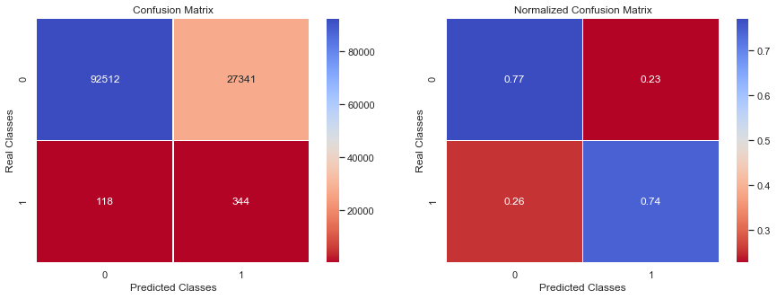

```
---------------------- Results and Summary -----------------------
---------------------------- Accuracy ----------------------------
77.17739999999999%


------------------- Classification Report --------------------
             precision    recall  f1-score   support

        0.0       1.00      0.77      0.87    119853
        1.0       0.01      0.74      0.02       462

avg / total       0.99      0.77      0.87    120315
```

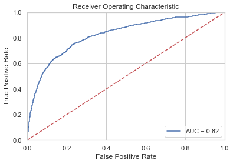

```python
Plot_Confusion_Matrix(LR_SMOTE,X_test,y_test)
Plot_ROC_Curve(LR_SMOTE, X_test, y_test)
Save_pkl_txt_files(LR_SMOTE,X_test,y_test,X_train,features_name,"LR_SMOTE_FM_Model", "Logistic Regression - SMOTE")
```